# Temporal and spatial data

Peter Ralph

12 March 2019 – Advanced Biological Statistics

# Modeling time series

## Time series

A *time series* is a sequence of observations
$$\begin{aligned}
(y_1, y_2, \ldots, y_N) ,
\end{aligned}$$
that were taken at some set of *times*
$$\begin{aligned}
t_1 < t_2 < \cdots < t_N .
\end{aligned}$$

In general, the goal is to understand how *what happens next* depends on the *previous history* and maybe some *predictor* variables
$$\begin{aligned}
(x_1, x_2, \ldots, x_N) ,
\end{aligned}$$
taken at the same set of times.

# An oscillator

## A discrete, noisy oscillator

Suppose we have regular, noisy observations from a discrete, noisy oscillator.

The system itself does
$$\begin{aligned}
x_{t+1} - x_t &= \alpha y_t + \Normal(0, \sigma_{xy}) \\
y_{t+1} - y_t &= - \beta x_t + \Normal(0, \sigma_{xy})
\end{aligned}$$
but we only get to observe
$$\begin{aligned}
X_t &= x_t + \Normal(0, \sigma_\epsilon) \\
Y_t &= y_t + \Normal(0, \sigma_\epsilon) .
\end{aligned}$$

Here’s what this looks like.

```r
true_osc <- list(alpha=.1,
                 beta=.05,
                 sigma_xy=.01,
                 sigma_eps=.1)
N <- 500
xy <- matrix(nrow=N, ncol=2)
xy[1,] <- c(3,0)
for (k in 1:(N-1)) {
    xy[k+1,] <- (xy[k,]
                + c(true_osc$alpha * xy[k,2],
                    (-1) * true_osc$beta * xy[k,1])
                + rnorm(2, 0, true_osc$sigma_xy))
}
XY <- xy + rnorm(N*2, 0, true_osc$sigma_eps)
```

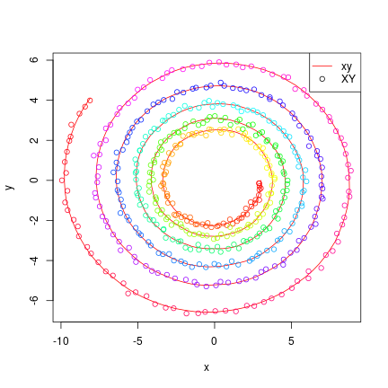

## A Stan block

```r
osc_block <- "
data {
    int N;
    vector[N] X;
    vector[N] Y;
}
parameters {
    real alpha;
    real beta;
    real<lower=0> sigma_xy;
    real<lower=0> sigma_eps;
    vector[N] x;
    vector[N] y;
}
model {
    x[2:N] ~ normal(x[1:(N-1)] + alpha * y[1:(N-1)], sigma_xy);
    y[2:N] ~ normal(y[1:(N-1)] - beta * x[1:(N-1)], sigma_xy);
    X ~ normal(x, sigma_eps);
    Y ~ normal(y, sigma_eps);
    alpha ~ normal(0, 1);
    beta ~ normal(0, 1);
    sigma_xy ~ normal(0, 1);
    sigma_eps ~ normal(0, 1);
}
"
osc_model <- stan_model(model_code=osc_block)
```

[output not shown]

```r
osc_fit <- sampling(osc_model,
                    data=list(N,
                              X=XY[,1],
                              Y=XY[,2]),
                    iter=1000, chains=3,
                    control=list(max_treedepth=12))
```

[output not shown]

## How’d we do?

```r
cbind(rstan::summary(osc_fit, pars=c("alpha", "beta", "sigma_xy", "sigma_eps"))$summary,
      truth=c(true_osc$alpha, true_osc$beta, true_osc$sigma_xy, true_osc$sigma_eps))
```

[output not shown]

[output not shown]

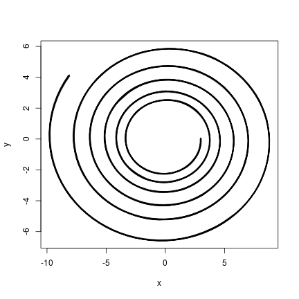

[output not shown]

# A noisier oscillator

## More realism?

Let’s try that again, with more noise.

Here’s what this looks like.

```r
true_osc2 <- list(alpha=.1,
                 beta=.05,
                 sigma_xy=2.0,
                 sigma_eps=4.0)
xy2 <- matrix(nrow=N, ncol=2)
xy2[1,] <- c(3,0)
for (k in 1:(N-1)) {
    xy2[k+1,] <- (xy2[k,]
                + c(true_osc2$alpha * xy2[k,2],
                    (-1) * true_osc2$beta * xy2[k,1])
                + rnorm(2, 0, true_osc2$sigma_xy))
}
XY2 <- xy2 + rnorm(N*2, 0, true_osc2$sigma_eps)
```

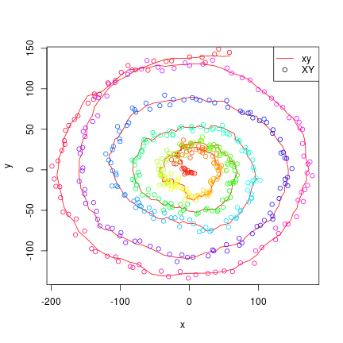

```r
osc_fit2 <- sampling(osc_model,
                    data=list(N,
                              X=XY2[,1],
                              Y=XY2[,2]),
                    iter=1000, chains=3,
                    control=list(max_treedepth=12))
```

[output not shown]

## How’d we do?

```r
cbind(rstan::summary(osc_fit2, pars=c("alpha", "beta", "sigma_xy", "sigma_eps"))$summary,
      truth=c(true_osc2$alpha, true_osc2$beta, true_osc2$sigma_xy, true_osc2$sigma_eps))
```

[output not shown]

Here is a density plot of 100 estimated trajectories (of `x` and `y`) from the Stan fit.

[output not shown]

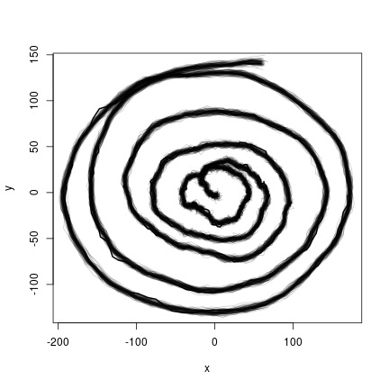

[output not shown]

# Missing data

## Even more realism?

Now what if we actually *don’t observe* most of the $Y$ values?

Here’s what this looks like.

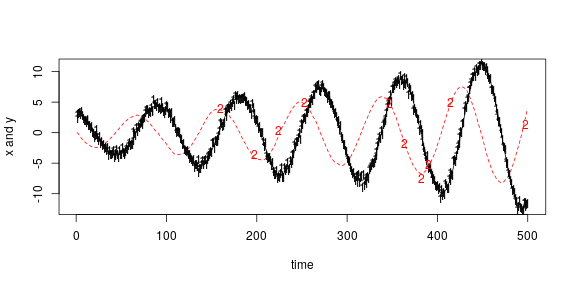

```r
true_osc3 <- list(alpha=.1,
                 beta=.05,
                 sigma_xy=.05,
                 sigma_eps=.5)
xy3 <- matrix(nrow=N, ncol=2)
xy3[1,] <- c(3,0)
for (k in 1:(N-1)) {
    xy3[k+1,] <- (xy3[k,]
                + c(true_osc3$alpha * xy3[k,2],
                    (-1) * true_osc3$beta * xy3[k,1])
                + rnorm(2, 0, true_osc3$sigma_xy))
}
XY3 <- xy3 + rnorm(N*2, 0, true_osc3$sigma_eps)
obs_y <- sample.int(N, size=10)
XY3[setdiff(1:N, obs_y), 2] <- NA
```

## A new Stan block

```r
osc_block_missing <- "
data {
    int N;
    vector[N] X;
    int k; // number of observed Y
    int obs_y[k]; // which Y values are observed
    vector[k] Y;
}
parameters {
    real alpha;
    real beta;
    real<lower=0> sigma_xy;
    real<lower=0> sigma_eps;
    vector[N] x;
    vector[N] y;
}
model {
    x[2:N] ~ normal(x[1:(N-1)] + alpha * y[1:(N-1)], sigma_xy);
    y[2:N] ~ normal(y[1:(N-1)] - beta * x[1:(N-1)], sigma_xy);
    X ~ normal(x, sigma_eps);
    Y ~ normal(y[obs_y], sigma_eps);
    alpha ~ normal(0, 1);
    beta ~ normal(0, 1);
    sigma_xy ~ normal(0, 1);
    sigma_eps ~ normal(0, 1);
}
"
osc_model_missing <- stan_model(model_code=osc_block_missing)
```

[output not shown]

```r
osc_fit3 <- sampling(osc_model_missing,
                    data=list(N,
                              X=XY3[,1],
                              k=length(obs_y),
                              obs_y=obs_y,
                              Y=XY3[obs_y,2]),
                    iter=1000, chains=3,
                    control=list(max_treedepth=12))
```

[output not shown]

## How’d we do?

```r
cbind(rstan::summary(osc_fit3, pars=c("alpha", "beta", "sigma_xy", "sigma_eps"))$summary,
      truth=c(true_osc3$alpha, true_osc3$beta, true_osc3$sigma_xy, true_osc3$sigma_eps))
```

[output not shown]

Here is a density plot of 100 estimated trajectories (of `x` and `y`) from the Stan fit.

[output not shown]

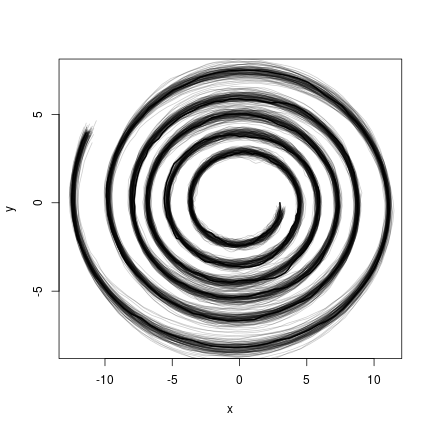

[output not shown]

# Spatial models

## A simple scenario

Suppose we have estimates of abundance of a soil microbe from a number of samples across our study area:

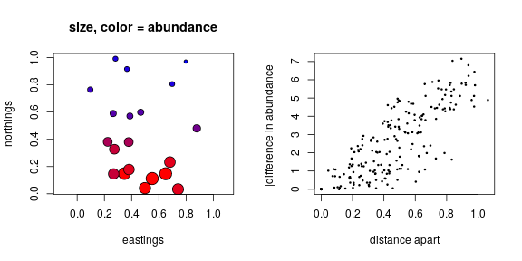

## The data

`(x,y)` : spatial coords; `z` : abundance

```r
xy
```

```
##             x          y         z
## 1  0.36570561 0.91601951  4.203546
## 2  0.34674591 0.14804962  9.677145
## 3  0.28120674 0.99160415  4.202536
## 4  0.09618601 0.76485639  4.562420
## 5  0.37855554 0.37953143  7.309844
## 6  0.27307616 0.32704858  7.990845
## 7  0.26440936 0.58937968  5.235354
## 8  0.69809336 0.80556321  4.150339
## 9  0.74084430 0.03327871  9.092326
## 10 0.22440814 0.38113112  7.268042
## 11 0.65007941 0.14698290  9.917480
## 12 0.55097394 0.11196825 10.030375
## 13 0.38075338 0.17814633  8.662223
## 14 0.68119877 0.23249908  8.836484
## 15 0.38755934 0.57082907  5.065999
## 16 0.49790287 0.04134980  9.315853
## 17 0.79792488 0.97102161  2.878486
## 18 0.46672735 0.59853551  5.155774
## 19 0.87866343 0.48030911  6.187081
## 20 0.26769967 0.14591511  8.578937
```

**Goals:**

1. (descriptive) What spatial scale does abundance vary over?
2. (predictive) What are the likely (range of) abundances at new locations?

# Spatial covariance

## Tobler’s First Law of Geography:

> Everything is related to everything else, but near things are more related than distant things.

*Modeler:* Great, covariance is a decreasing function of distance.

## A decreasing function of distance.

A convenient choice: the covariance between two points distance $d$ apart is
$$\begin{aligned}
\alpha^2 \exp\left(- \frac{1}{2}\left(\frac{d}{\rho}\right)^2 \right) .
\end{aligned}$$

- $\alpha$ controls the overall variance (amount of noise)
- $\rho$ is the spatial scale that covariance decays over

## In Stan

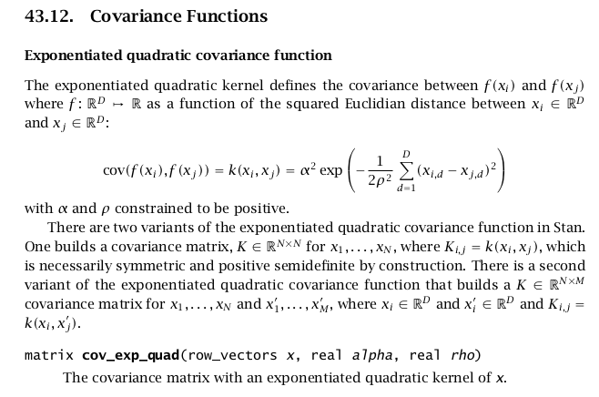

cov_exp_quad() documentation

Here’s an `R` function that takes a set of locations (`xy`), a variance scaling `alpha`, and a spatial scale `rho`:

```r
cov_exp_quad <- function (xy, alpha, rho) {
    # return the 'quadratic exponential' covariance matrix
    # for spatial positions xy
    dxy <- as.matrix(dist(xy))
    return( alpha^2 * exp( - (1/2) * dxy^2 / rho^2 ) )
}
```

**Challenge:** simulate spatially autocorrelated random Gaussian values, and plot them, in space. Pick parameters so you can tell they are autocorrelated.

*to color points by a continuous value:*

```
     colorRampPalette(c('blue', 'red'))(24)[cut(xy$z, breaks=24)]
```

## Simulation

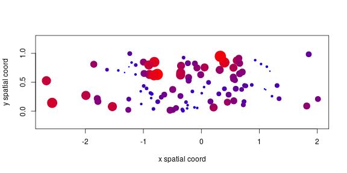

```r
library(mvtnorm)
N <- 100
# spatial extent of order 1
xy <- data.frame(y=runif(N),
                 x=rnorm(N))
rho <- .25
alpha <- 1.0
# compute covariance matrix
K <- cov_exp_quad(xy, alpha, rho)
# simulate z's
xy$z <- as.vector(rmvnorm(1, mean=rep(0,N),
                          sigma=K))
plot(xy$x, xy$y, xlab='x spatial coord',
     ylab='y spatial coord', pch=20, asp=1,
     cex=as.numeric(cut(xy$z, breaks=10))/2,
     col=colorRampPalette(c('blue', 'red'))(24)[cut(xy$z, breaks=24)])
```

## Simulation number 2

```r
library(mvtnorm)
N <- 1000
# spatial extent of order 1
xy <- data.frame(x=runif(N),
                 y=rnorm(N))
rho <- .25
alpha <- 1.0
# compute covariance matrix
K <- cov_exp_quad(xy, alpha, rho)
# simulate z's
xy$z <- as.vector(rmvnorm(1, mean=rep(0,N),
                          sigma=K))
```

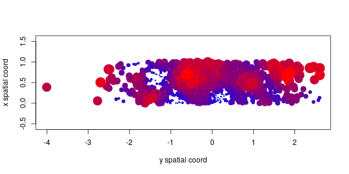

```r
plot(xy$y, xy$x, xlab='y spatial coord',
     ylab='x spatial coord', pch=20, asp=1,
     cex=as.numeric(cut(xy$z, breaks=10))/2,
     col=colorRampPalette(c('blue', 'red'))(24)[cut(xy$z, breaks=24)])
```

# Back to the data

## Goals

1. (descriptive) What spatial scale does abundance vary over?

   $\Rightarrow$ What is $\rho$?
2. (predictive) What are the likely (range of) abundances at new locations?

   $\Rightarrow$ Add unobserved abundances as *parameters*.

## A basic Stan block

```r
sp_block <- "
data {
    int N; // number of obs
    vector[2] xy[N]; // spatial pos
    vector[N] z;
}
parameters {
    real<lower=0> alpha;
    real<lower=0> rho;
}
model {
    matrix[N, N] K;
    K = cov_exp_quad(xy, alpha, rho);

    z ~ multi_normal(rep_vector(0.0, N), K);
    alpha ~ normal(0, 5);
    rho ~ normal(0, 5);
}
"
# check this compiles
sp_model <- stan_model(model_code=sp_block)
```

[output not shown]

**Challenge:** we would like to estimate the abundance at the `k` locations `new_xy`. Add this feature to the Stan block.

```
data {
    int N; // number of obs
    vector[2] xy[N]; // spatial pos
    vector[N] z;
}
parameters {
    real<lower=0> alpha;
    real<lower=0> rho;
}
model {
    matrix[N, N] K;
    K = cov_exp_quad(xy, alpha, rho);

    z ~ multi_normal(rep_vector(0.0, N), K);
    alpha ~ normal(0, 5);
    rho ~ normal(0, 5);
}
```

## A solution

```r
sp_block <- "
data {
    int N; // number of obs
    vector[2] old_xy[N]; // spatial pos
    vector[N] old_z;
    int n;
    vector[2] new_xy[n]; // new locs
}
transformed data {
    vector[2] xy[N+n];
    xy[1:N] = old_xy;
    xy[(N+1):(N+n)] = new_xy;
    print(dims(old_z));
}
parameters {
    real<lower=0> alpha;
    real<lower=0> rho;
    vector[n] new_z;
    real<lower=0> delta;
    real mu;
}
model {
    matrix[N+n, N+n] K;
    vector[N+n] z;
    K = cov_exp_quad(xy, alpha, rho);
    for (k in 1:(N+n)) {
        K[k,k] += delta;
    }
    z[1:N] = old_z;
    z[(N+1):(N+n)] = new_z;
    z ~ multi_normal(rep_vector(mu, N+n), K);
    alpha ~ normal(0, 5);
    rho ~ normal(0, 5);
    delta ~ normal(0, 5);
    mu ~ normal(0, 5);
}
"

new_sp <- stan_model(model_code=sp_block)
```

[output not shown]

## Simulate data

```r
library(mvtnorm)
N <- 20
xy <- data.frame(x=runif(N), y=runif(N))
dxy <- as.matrix(dist(xy))
ut <- upper.tri(dxy, diag=TRUE)
truth <- list(rho=.6,
              delta=.1,
              alpha=2.5,
              mu=5)
truth$covmat <- (truth$delta * diag(N)
                 + truth$alpha^2 * exp(-(dxy/truth$rho)^2))
xy$z <- as.vector(rmvnorm(1, mean=rep(truth$mu,N), sigma=truth$covmat))
```

## It runs.

```r
new_xy <- cbind(x=runif(5), y=runif(5))
sp_data <- list(N=nrow(xy),
                old_xy=cbind(xy$x, xy$y),
                old_z=xy$z,
                n=nrow(new_xy),
                new_xy=as.matrix(new_xy))

(sp_time <- system.time(
    sp_fit <- sampling(new_sp,
                       data=sp_data,
                       iter=1000,
                       chains=2,
                       control=list(adapt_delta=0.99,
                                    max_treedepth=12))))
```

[output not shown]

[output not shown]

## Does it work?

```r
cbind(truth=truth[c("alpha", "rho", "delta", "mu")],
      rstan::summary(sp_fit, pars=c("alpha", "rho", "delta", "mu"))$summary)
```

[output not shown]

[output not shown]

[output not shown]

[figure not shown]